# Predicting Annual Donor Pledge Amounts

- Show All Code
- Hide All Code
- View Source

A Machine Learning Approach to Fundraising Analytics

Author

Manolo Vasquez

Published

May 1, 2026

## Project Overview

Every year, fundraising teams at donor-driven organizations face the same challenge: *who should we contact, when, and how much effort should we invest in each donor?* Without a systematic approach, outreach strategies rely on intuition or simple rules — “contact everyone who gave last year” — which misses opportunities and wastes agent time.

This project builds a machine learning pipeline to answer two questions for **Anonymous Organization**:

1. **How much is each donor likely to pledge next year?**
2. **Which donors deserve priority outreach, and which are already low-maintenance?**

Using 10 years of historical donation records (2014–2025) joined from six relational tables, I trained an XGBoost regression model that achieved **MAE ≈ $1,145** on held-out 2024 data — substantially better than simply repeating the prior year’s pledge. The final deliverable is a segmentation table that categorizes each donor into one of four actionable quadrants for the fundraising team.

## Data Architecture & SQL Feature Engineering

The central engineering challenge was building **temporal features** from the pledge history — lagged values, year-over-year growth rates, and rolling averages — while ensuring no future information leaked into the past. All of this was done in MySQL before handing off to Python.

### Temporal Feature Engineering (`ten_year_features`)

The most critical table. For each donor-year combination, we compute:

- `Lag1_Pledge` through `Lag5_Pledge`: prior-year pledge amounts using `LAG()` window functions
- `Avg_pledges_3years`: rolling 3-year average (handles missing years via `NULLIF`)
- `Avg_pct_increase_5years`: average year-over-year growth rate over 5 years
- `insufficient_history`: flag for donors with fewer than 5 years of data

```sql
CREATE TABLE ten_year_features AS
SELECT
    *,
    IF(YearsCount < 5 OR Avg_pct_increase_5years IS NULL, 1, 0) AS insufficient_history
FROM (
    SELECT
        FanID, DriveYear, Num_group_donating, Last_payment_date, TotalPledgeAnual, L1,
        next_year_donation, MaxYear, MinYear, YearsCount,
        (COALESCE(L1, 0) + COALESCE(L2, 0) + COALESCE(L3, 0)) /
        NULLIF(
            (CASE WHEN L1 IS NOT NULL THEN 1 ELSE 0 END) +
            (CASE WHEN L2 IS NOT NULL THEN 1 ELSE 0 END) +
            (CASE WHEN L3 IS NOT NULL THEN 1 ELSE 0 END),
        0) AS Avg_pledges_3years,
        (
            COALESCE(growth_1, 0) + COALESCE(growth_2, 0) +
            COALESCE(growth_3, 0) + COALESCE(growth_4, 0) +
            COALESCE(growth_5, 0)
        ) /
        NULLIF(
            (CASE WHEN growth_1 IS NOT NULL THEN 1 ELSE 0 END) +
            (CASE WHEN growth_2 IS NOT NULL THEN 1 ELSE 0 END) +
            (CASE WHEN growth_3 IS NOT NULL THEN 1 ELSE 0 END) +
            (CASE WHEN growth_4 IS NOT NULL THEN 1 ELSE 0 END) +
            (CASE WHEN growth_5 IS NOT NULL THEN 1 ELSE 0 END),
        0) AS Avg_pct_increase_5years
    FROM (
        SELECT
            *,
            ((TotalPledgeAnual - NULLIF(L1,0)) / NULLIF(L1,0) * 100) AS growth_1,
            ((L1 - NULLIF(L2,0)) / NULLIF(L2,0) * 100) AS growth_2,
            ((L2 - NULLIF(L3,0)) / NULLIF(L3,0) * 100) AS growth_3,
            ((L3 - NULLIF(L4,0)) / NULLIF(L4,0) * 100) AS growth_4,
            ((L4 - NULLIF(L5,0)) / NULLIF(L5,0) * 100) AS growth_5
        FROM (
            SELECT
                FanID, DriveYear, TotalPledgeAnual, Last_payment_date, Num_group_donating,
                MIN(DriveYear) OVER(PARTITION BY FanID) as MinYear,
                MAX(DriveYear) OVER(PARTITION BY FanID) as MaxYear,
                COUNT(DriveYear) OVER(PARTITION BY FanID) as YearsCount,
                LEAD(TotalPledgeAnual) OVER (PARTITION BY FanID ORDER BY DriveYear) AS next_year_donation,
                LAG(TotalPledgeAnual, 1) OVER (PARTITION BY FanID ORDER BY DriveYear) AS L1,
                LAG(TotalPledgeAnual, 2) OVER (PARTITION BY FanID ORDER BY DriveYear) AS L2,
                LAG(TotalPledgeAnual, 3) OVER (PARTITION BY FanID ORDER BY DriveYear) AS L3,
                LAG(TotalPledgeAnual, 4) OVER (PARTITION BY FanID ORDER BY DriveYear) AS L4,
                LAG(TotalPledgeAnual, 5) OVER (PARTITION BY FanID ORDER BY DriveYear) AS L5
            FROM (
                SELECT
                    FanID, DriveYear,
                    SUM(PledgeAmount) AS TotalPledgeAnual,
                    MAX(MostRecentPaymentPledgeDate) AS Last_payment_date,
                    COUNT(FundGroupName) AS Num_group_donating
                FROM ten_year_donation
                GROUP BY FanID, DriveYear
            ) AS agrupado
        ) AS con_lags
    ) AS con_growths
) AS final_step;
```

### Supporting Dimension Tables

**Education** — collapsed to a single row per donor by highest degree, with an ordinal rank (Doctoral → 3, Master’s → 2, Bachelor’s → 1):

```sql
CREATE TABLE education_final AS
WITH ranked AS (
    SELECT
        FanID, EducationStatus, Degree, DegreeType, College,
        CASE
            WHEN Degree LIKE '%Doctor%' THEN 3
            WHEN Degree LIKE '%Master%' THEN 2
            WHEN Degree LIKE '%Bachelor%' THEN 1
            ELSE 0
        END AS DegreeRank
    FROM education
    WHERE DegreeType = 'PRIMARY'
)
SELECT FanID, EducationStatus, Degree, College
FROM (
    SELECT *, ROW_NUMBER() OVER (PARTITION BY FanID ORDER BY DegreeRank DESC) AS rn
    FROM ranked
) t
WHERE rn = 1;
```

**Board Membership** — binary flag + whether the donor is currently active on the board:

```sql
CREATE TABLE board_members_final AS
SELECT
    FanID,
    1 AS was_board_member,
    MAX(CurrentFlag) AS CurrentFlag
FROM board_members
GROUP BY FanID;
```

**Wealth** — IWave wealth indicators with a null flag (missing data is itself a signal):

```sql
CREATE TABLE wealth_final AS
SELECT FanID, IWave_Properties, IWave_PropertiesValue,
       IWave_AnnualCapacityTargetProduction,
       IF(IWave_PropertiesValue IS NULL, 1, 0) AS Properties_null
FROM wealth;
```

### Final Modeling Table Assembly

```sql
CREATE TABLE donations_df AS
SELECT
    t.FanID, t.DriveYear, t.Num_group_donating,
    COALESCE(t.L1, 0) AS Lag1_Pledge,
    CASE WHEN t.L1 IS NULL THEN 1 ELSE 0 END AS Lag1_null,
    t.TotalPledgeAnual, t.next_year_donation, t.MaxYear, t.MinYear, t.YearsCount,
    COALESCE(t.Avg_pledges_3years, 0)      AS Avg_pledges_3years,
    COALESCE(t.Avg_pct_increase_5years, 0) AS Avg_pct_increase_5years,
    t.insufficient_history,
    e.EducationStatus, e.Degree, e.College,
    COALESCE(b.was_board_member, 0)  AS was_board_member,
    COALESCE(b.CurrentFlag, 0)       AS CurrentFlag,
    COALESCE(w.IWave_Properties, 0)  AS IWave_Properties,
    COALESCE(w.IWave_PropertiesValue, 0) AS IWave_PropertiesValue,
    COALESCE(w.IWave_AnnualCapacityTargetProduction, 0) AS IWave_AnnualCapacityTargetProduction,
    COALESCE(w.Properties_null, 1)   AS Properties_null,
    d.Age, bf.state, bf.YearsOfDonating,
    bf.HighestMembershipLevel, bf.MostRecentMembershipLevel,
    bf.CYAnnualFundPledged, bf.CYAnnualFundPaid, bf.IsAlumni
FROM ten_year_features t
    LEFT JOIN education_final e    ON t.FanID = e.FanID
    LEFT JOIN board_members_final b ON t.FanID = b.FanID
    LEFT JOIN wealth_final w        ON t.FanID = w.FanID
    LEFT JOIN demographic d         ON t.FanID = d.FanID
    LEFT JOIN base_final bf         ON t.FanID = bf.FanID
WHERE t.next_year_donation IS NOT NULL
  AND t.DriveYear BETWEEN 2014 AND 2024;
```

## Exploratory Data Analysis

Before building any model, we needed to validate several assumptions about the data structure and answer key design questions that would shape the entire pipeline.

### Problem Framing: Why Regression, Not Classification?

The initial instinct was to predict *whether* a donor would comply with their pledge. After checking the data, that approach was rejected immediately.

```python
non_compliance_rate = (
    (ten_year_donation['PaymentAmount'] < ten_year_donation['PledgeAmount']).mean()
)
print(f"Non-compliance rate: {non_compliance_rate:.2%}")
# Result: Non-compliance rate: 3.02% → Too imbalanced for classification
```

```
Non-compliance rate: 3.05%
```

Only 3% of pledge-year combinations show non-compliance. A classifier trained on this would simply predict “compliant” for everyone and achieve 97% accuracy — a useless model. The regression framing (predict *how much* they’ll pledge) was adopted instead.

### Donor Population Scope

```python
donors_with_history = ten_year_donation['FanID'].nunique()   # ~45,000
total_in_base       = base_table['FanID'].nunique()          # ~706,000
print(f"Total donors in base: {total_in_base:,}")
print(f"Donors with pledge history: {donors_with_history:,} ({donors_with_history/total_in_base:.2%} of total)")
```

```
Total donors in base: 706,118
Donors with pledge history: 45,806 (6.49% of total)
```

The model applies to roughly 6% of the total database — active donors with a pledge track record in the last 10 years. The remaining 93% fall outside scope: they have no donation history.

### Target Distribution and the Case for `log1p`

Donation amounts span from a few dollars to over $790,000. The raw distribution is extremely right-skewed — as the histogram above confirms, the vast majority of donors cluster near $0 while a handful of mega-donors extend the tail past $350,000. Computing any loss function in dollar scale would let those outliers dominate the model entirely.

Applying `log1p` compresses the range and stabilizes variance. The second histogram shows the transformed distribution shifting toward a near-normal shape centered around `log1p ≈ 6–7`, which corresponds roughly to $400–$1,100 in the original scale — the typical giving range for most donors in this dataset. This transformation allows the model to learn meaningful patterns across the entire donor spectrum, rather than being overwhelmed by a few extreme values.

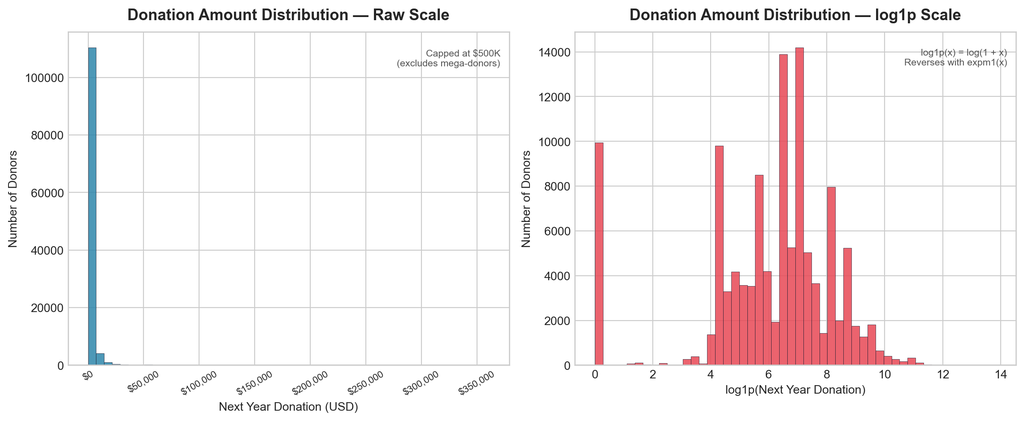

Figure 1: Left: raw donation amounts (capped at $500K). Right: log1p-transformed distribution showing near-normal shape centered around typical giving range.

```python
FILL_RAW  = "#2E86AB"
FILL_LOG  = "#E84855"
BORDER    = "#1A1A2E"

df1 = df.copy()
df1['next_year_donation_log'] = np.log1p(df1['next_year_donation'])

fig, (ax1, ax2) = plt.subplots(1, 2, figsize=(12, 5))

# Raw scale
raw_data = df[(df['next_year_donation'] >= 0) & (df['next_year_donation'] < 500_000)]['next_year_donation']
ax1.hist(raw_data, bins=50, color=FILL_RAW, edgecolor=BORDER, alpha=0.85, linewidth=0.3)
ax1.xaxis.set_major_formatter(mticker.FuncFormatter(lambda x, _: f'${x:,.0f}'))
ax1.tick_params(axis='x', labelrotation=30, labelsize=8)
ax1.set_title('Donation Amount Distribution — Raw Scale', fontsize=13, fontweight='bold', pad=10)
ax1.set_xlabel('Next Year Donation (USD)', fontsize=10)
ax1.set_ylabel('Number of Donors', fontsize=10)
ax1.text(0.98, 0.95, 'Capped at $500K\n(excludes mega-donors)',
         transform=ax1.transAxes, ha='right', va='top', fontsize=8, color='#555555')
# log1p scale
ax2.hist(df1['next_year_donation_log'], bins=50, color=FILL_LOG, edgecolor=BORDER, alpha=0.85, linewidth=0.3)
ax2.set_title('Donation Amount Distribution — log1p Scale', fontsize=13, fontweight='bold', pad=10)
ax2.set_xlabel('log1p(Next Year Donation)', fontsize=10)
ax2.set_ylabel('Number of Donors', fontsize=10)
ax2.text(0.98, 0.95, 'log1p(x) = log(1 + x)\nReverses with expm1(x)',
         transform=ax2.transAxes, ha='right', va='top', fontsize=8, color='#555555')

plt.tight_layout()
plt.show()
plt.close()
```

### Reliability Threshold for Segmentation

To define “reliable” donors, we computed each donor’s track record: in what fraction of years did they actually pay what they pledged?

```python
# ── Historical reliability distribution ──────────────────────────────────────
# Used to define the reliability threshold for donor segmentation.
max_year = 2024
min_year = max_year - 9
td_10y = ten_year_donation[ten_year_donation['DriveYear'].between(min_year, max_year)].copy()

fan_year = (
    td_10y.groupby(['FanID', 'DriveYear'], as_index=False)
    .agg(PledgeAmount=('PledgeAmount', 'sum'), PaymentAmount=('PaymentAmount', 'sum'))
)
fan_year = fan_year[fan_year['PledgeAmount'] > 0].copy()
fan_year['met_commitment'] = (fan_year['PaymentAmount'] >= fan_year['PledgeAmount']).astype(int)

fan_reliability = (
    fan_year.groupby('FanID', as_index=False)
    .agg(years_with_pledge=('DriveYear', 'nunique'), years_met=('met_commitment', 'sum'))
)
fan_reliability['pct_years_met_commitment'] = (
    100 * fan_reliability['years_met'] / fan_reliability['years_with_pledge']
)

perfect_pct = (fan_reliability['pct_years_met_commitment'] == 100).mean() * 100
print(f"Donors with 100% commitment rate: {perfect_pct:.1f}%")
print(f"→ Threshold set at 100% (binary: perfect vs. any miss)")
print(f"\nReliability distribution:")
print(fan_reliability['pct_years_met_commitment'].describe())

# → 90.9% of donors have a 100% commitment rate
```

```
Donors with 100% commitment rate: 96.6%
→ Threshold set at 100% (binary: perfect vs. any miss)

Reliability distribution:
count    35187.000000
mean        98.217442
std         11.308705
min          0.000000
25%        100.000000
50%        100.000000
75%        100.000000
max        100.000000
Name: pct_years_met_commitment, dtype: float64
```

## Feature Engineering & Preprocessing

The modeling table required substantial transformation before it could be fed into any algorithm. The table below summarizes every design decision and the rationale behind it.

Feature engineering decisions

[output not shown]

### Key Design Choices

**Why ordinal encoding for membership levels?** The organization uses a named tier system (Legacy Chief, Platinum Chief, …, Spirit) with a clear hierarchy. Treating this as nominal would discard that signal. The ordinal mapping mirrors the actual tier structure.

**Why temporal split instead of random?** A random 80/20 split would let the model see 2024 donors in training and predict their 2024 behavior — trivially easy and completely misleading. The temporal split simulates real deployment: train on past, validate on the next year, hold out the most recent year.

**Why flag missingness instead of imputing?** For `Age` (23% missing) and wealth scores, the absence of data is itself informative. A donor without an age record differs systematically from one with a known age. Adding a `_null` binary flag lets the model learn from that pattern.

```python
# ── Membership ordinal mapping ────────────────────────────────────────────────
MEMBERSHIP_MAPPING = {
    'Legacy Chief': 10, 'Platinum Chief': 9, 'Golden Chief': 8,
    'Silver Chief': 7,  'Tomahawk': 6,       'Warrior': 5,
    'Renegade': 4,      'Brave': 3,           'Iron Arrow': 2,
    'Spirit': 1,        np.nan: 0,            '': 0,
}

def classify_degree(degree):
    """Map degree name to ordinal level (0=unknown → 4=doctoral)."""
    if pd.isna(degree): return 0
    degree = degree.lower()
    if 'doctor' in degree or 'juris' in degree or 'ph.d' in degree: return 4
    if 'master' in degree or 'mba'   in degree:                      return 3
    if 'bachelor' in degree:                                          return 2
    if 'associate' in degree:                                         return 1
    return 0

# ── Build processed dataframe ─────────────────────────────────────────────────
df_processed = df.copy()
df_processed['Age']      = pd.to_numeric(df_processed['Age'], errors='coerce')
df_processed['Age_null'] = df_processed['Age'].isnull().astype(int)

df_processed['Degree_encoded']                    = df_processed['Degree'].apply(classify_degree)
df_processed['HighestMembershipLevel_encoded']    = df_processed['HighestMembershipLevel'].map(MEMBERSHIP_MAPPING)
df_processed['MostRecentMembershipLevel_encoded'] = df_processed['MostRecentMembershipLevel'].map(MEMBERSHIP_MAPPING)

education_dummies = pd.get_dummies(
    df_processed[['EducationStatus', 'College']],
    prefix=['EducationStatus', 'College'],
    drop_first=False
)
df_processed = pd.concat([df_processed, education_dummies], axis=1)

# ── Regional encoding ─────────────────────────────────────────────────────────
NORTHEAST = ['CT','ME','MA','NH','RI','VT','NJ','NY','PA']
SOUTHEAST = ['DE','MD','DC','VA','WV','NC','SC','GA','AL','MS','LA','AR','TN','KY','TX']
MIDWEST   = ['OH','IN','IL','MI','WI','MN','IA','MO','ND','SD','NE','KS']
WEST      = ['MT','WY','CO','NM','AZ','UT','NV','CA','OR','WA','ID','AK','HI']

df_processed['is_florida']       = (df_processed['state'] == 'FL').astype(int)
df_processed['region_northeast'] = df_processed['state'].isin(NORTHEAST).astype(int)
df_processed['region_southeast'] = df_processed['state'].isin(SOUTHEAST).astype(int)
df_processed['region_midwest']   = df_processed['state'].isin(MIDWEST).astype(int)
df_processed['region_west']      = df_processed['state'].isin(WEST).astype(int)

# ── Boolean columns ───────────────────────────────────────────────────────────
for col in ['insufficient_history', 'Lag1_null', 'Properties_null', 'was_board_member', 'CurrentFlag']:
    df_processed[col] = df_processed[col].astype(int)
df_processed['IsAlumni'] = (df_processed['IsAlumni'] == 'Y').astype(int)

print(f"Processed dataset shape: {df_processed.shape}")
```

```
Processed dataset shape: (116890, 62)
```

## Pipeline Overview

```python
# ── Temporal train / validation / holdout split ───────────────────────────────
# Note: random split would cause data leakage — time ordering must be preserved.
NUMERIC_FEATURES  = [
    'Num_group_donating', 'Lag1_Pledge', 'TotalPledgeAnual', 'YearsCount',
    'Avg_pledges_3years', 'Avg_pct_increase_5years', 'YearsOfDonating', 'Age',
    'IWave_Properties', 'IWave_PropertiesValue', 'IWave_AnnualCapacityTargetProduction'
]
BOOLEAN_FEATURES  = [
    'insufficient_history', 'Lag1_null', 'Properties_null',
    'was_board_member', 'CurrentFlag', 'IsAlumni', 'Age_null'
]
ORDINAL_FEATURES  = [
    'HighestMembershipLevel_encoded', 'MostRecentMembershipLevel_encoded', 'Degree_encoded'
]
EDUCATION_FEATURES = [c for c in df_processed.columns if c.startswith('EducationStatus_')]
COLLEGE_FEATURES   = [c for c in df_processed.columns if c.startswith('College_')]
REGION_FEATURES    = ['is_florida', 'region_northeast', 'region_southeast', 'region_midwest', 'region_west']

ALL_FEATURES = (NUMERIC_FEATURES + BOOLEAN_FEATURES + ORDINAL_FEATURES
                + EDUCATION_FEATURES + COLLEGE_FEATURES + REGION_FEATURES)

train_mask = (df_processed['DriveYear'] >= 2014) & (df_processed['DriveYear'] <= 2022)
val_mask   =  df_processed['DriveYear'] == 2023
test_mask  =  df_processed['DriveYear'] == 2024

X_train = df_processed[train_mask][ALL_FEATURES].copy()
X_val   = df_processed[val_mask][ALL_FEATURES].copy()
X_test  = df_processed[test_mask][ALL_FEATURES].copy()

y_train = df_processed[train_mask]['next_year_donation']
y_val   = df_processed[val_mask]['next_year_donation']
y_test  = df_processed[test_mask]['next_year_donation']

y_train_log = np.log1p(y_train)
y_val_log   = np.log1p(y_val)
y_test_log  = np.log1p(y_test)

# Age imputation — median computed on train only to prevent leakage
age_median = X_train['Age'].median()
for X in [X_train, X_val, X_test]:
    X['Age'] = X['Age'].fillna(age_median)

print(f"Train : {X_train.shape}  (DriveYear 2014–2023)")
print(f"Val   : {X_val.shape}  (DriveYear 2024)")
print(f"Test  : {X_test.shape}   (DriveYear 2025)")
print(f"Total features: {len(ALL_FEATURES)}")
print(f"\nRemaining nulls in train: {X_train.isnull().sum().sum()}")
```

```
Train : (91513, 49)  (DriveYear 2014–2023)
Val   : (12035, 49)  (DriveYear 2024)
Test  : (11739, 49)   (DriveYear 2025)
Total features: 49

Remaining nulls in train: 0
```

## Baseline Model — Ridge Regression

Before deploying a complex model, the first question to answer is simpler: *can a linear model explain donor behavior at all?* Ridge regression serves that purpose here — not as a serious candidate for production, but as a diagnostic tool to test whether the relationship between historical giving patterns and future pledges is approximately linear.

Ridge was chosen over plain OLS because three temporal features — `TotalPledgeAnual`, `Lag1_Pledge`, and `Avg_pledges_3years` — measure essentially the same signal at different points in time. Under OLS, that multicollinearity causes coefficients to inflate to unstable values that cancel each other out. Ridge’s L2 penalty forces all coefficients to be solved simultaneously with a constraint on their size, distributing moderate weights across correlated features rather than assigning an arbitrarily large weight to one and near-zero to the others.

```python
from sklearn.pipeline import Pipeline
from sklearn.preprocessing import StandardScaler
from sklearn.linear_model import Ridge
from sklearn.metrics import mean_squared_error, r2_score, mean_absolute_error

ridge_pipeline = Pipeline([
    ('scaler', StandardScaler()),
    ('ridge', Ridge(alpha=1.0))
])

ridge_pipeline.fit(X_train, y_train_log)

y_pred_train = ridge_pipeline.predict(X_train)
y_pred_val   = ridge_pipeline.predict(X_val)

print('--- TRAIN ---')
print('RMSE:', np.sqrt(mean_squared_error(y_train_log, y_pred_train)))
print('R²  :', r2_score(y_train_log, y_pred_train))
print('MAE :', mean_absolute_error(y_train_log, y_pred_train))

print('\n--- VAL ---')
print('RMSE:', np.sqrt(mean_squared_error(y_val_log, y_pred_val)))
print('R²  :', r2_score(y_val_log, y_pred_val))
print('MAE :', mean_absolute_error(y_val_log, y_pred_val))
```

```
--- TRAIN ---
RMSE: 1.9983320095740587
R²  : 0.3272720049291752
MAE : 1.3315902733151799

--- VAL ---
RMSE: 1.0594726062771591
R²  : 0.5894016784706303
MAE : 0.7750926027532766
```

```python
print("Varianza y_train_log:", y_train_log.var())
print("Varianza y_val_log  :", y_val_log.var())
print("Tamaño val          :", X_val.shape[0])
```

```
Varianza y_train_log: 5.936090792987951
Varianza y_val_log  : 2.733999192135807
Tamaño val          : 12035
```

```python
y_pred_val = ridge_pipeline.predict(X_val)

errores_dolar = np.abs(np.expm1(y_val_log) - np.expm1(y_pred_val))
print(f"MAE en dólares  : ${errores_dolar.mean():,.0f}")
print(f"Mediana error   : ${np.median(errores_dolar):,.0f}")
print(f"P75 error       : ${np.percentile(errores_dolar, 75):,.0f}")
print(f"P90 error       : ${np.percentile(errores_dolar, 90):,.0f}")
```

```
MAE en dólares  : $32,011
Mediana error   : $309
P75 error       : $1,053
P90 error       : $3,247
```

### Results & Interpretation

**A note on metrics:** MAE in dollar scale is dominated by a small number of mega-donors — a single prediction error on a $1M donor inflates the mean for everyone else. The median absolute error is the more honest operational metric: it describes the typical error for a randomly selected donor, unaffected by extremes.

| Metric | Value | Interpretation |
| --- | --- | --- |
| R² — Train | 0.33 | Model explains 33% of variance in training data |
| R² — Val | 0.59 | 2023 has lower variance (σ²=2.73) than train (σ²=5.94) — single year more homogeneous than a decade |
| Median error | $309 | Typical prediction is off by $309 on a $650 median donation |
| P90 error | $3,247 | 10% of donors have errors exceeding $3,247 |
| MAE (dollar) | $32,011 | Dominated by outliers — not a useful summary statistic here |

More importantly, R² of 0.33 on train data is low for a model evaluated on its own training set. This confirms the core finding: **donor giving behavior is not linearly separable.** A donor who gave $500 for five consecutive years behaves differently from one who gave $2,500 once — a distinction Ridge cannot capture because it treats all relationships as linear combinations of features.

This is precisely the gap XGBoost is designed to fill: non-linear interactions, heterogeneous donor profiles, and residual patterns that vary across the donation range.

## XGBoost Model

### Why XGBoost?

Three reasons XGBoost is better suited than Ridge for this problem:

1. **Non-linearity** — the relationship between past pledges and future pledges isn’t linear. A donor who gave $500 for 5 years behaves differently from one who gave $2,500 once.
2. **Heterogeneous profiles** — the donor population spans students, alumni, wealthy retirees, and board members. Tree-based methods handle this mixture naturally without feature scaling.
3. **Robust to skew** — sequential boosting iteratively corrects residuals, which works well when error patterns vary across the donation range.

### Hyperparameter Tuning

We ran `RandomizedSearchCV` with 25 candidate combinations and 3-fold cross-validation. Unlike the Ridge model which used RMSE, we optimize on **MAE** here — a deliberate choice justified in the evaluation section below.

```python
param_distributions = {
    'n_estimators':     [300, 500, 800, 1000],
    'learning_rate':    [0.01, 0.03, 0.05, 0.1],
    'max_depth':        [3, 4, 5, 6],
    'subsample':        [0.7, 0.8, 0.9, 1.0],
    'min_child_weight': [1, 3, 5],
    'reg_lambda':       [1, 1.5, 2],
}

random_search = RandomizedSearchCV(
    estimator=xgb.XGBRegressor(
        objective='reg:absoluteerror',
        random_state=42,
        n_jobs=-1
    ),
    param_distributions=param_distributions,
    n_iter=25,
    scoring='neg_mean_absolute_error',
    cv=3,
    verbose=1,
    random_state=42,
    n_jobs=-1,
)

random_search.fit(X_train, y_train_log)
xgb_reg = random_search.best_estimator_
```

```
Fitting 3 folds for each of 25 candidates, totalling 75 fits
```

### Model Evaluation

#### Why MAE and not RMSE?

RMSE squares each error before averaging, which means a single donor with a $748K prediction error can dominate the entire metric. In this dataset, that is not a theoretical concern — it is exactly what happens.

The choice of MAE is deliberate: it weights all absolute errors equally, which better reflects operational usefulness. A $500 error on a $600 pledge and a $500 error on a $100,000 pledge are treated the same, which is the right behavior when the goal is to prioritize outreach across the full donor population.

#### Full population results

```python
for name, X_split, y_split in [('Train', X_train, y_train_log),
                                ('Validation', X_val, y_val_log),
                                ('Test', X_test, y_test_log)]:
    y_pred      = xgb_reg.predict(X_split)
    y_pred_orig = np.expm1(y_pred)
    y_true_orig = np.expm1(y_split.values)
    rmse = np.sqrt(mean_squared_error(y_true_orig, y_pred_orig))
    mae  = np.mean(np.abs(y_true_orig - y_pred_orig))
    r2   = r2_score(y_true_orig, y_pred_orig)
    print(f"--- {name} ---")
    print(f"RMSE: ${rmse:,.0f}")
    print(f"MAE : ${mae:,.0f}")
    print(f"R²  : {r2:.3f}\n")
```

```
--- Train ---
RMSE: $5,059
MAE : $646
R²  : 0.491

--- Validation ---
RMSE: $4,358
MAE : $652
R²  : 0.640

--- Test ---
RMSE: $7,942
MAE : $1,146
R²  : 0.456
```

On the full population, test R² lands at 0.456 with a MAE of $1,146. The gap between RMSE ($7,942) and MAE ($1,146) is already a signal worth investigating: when those two metrics diverge this much, a small number of large errors are driving the RMSE up while most predictions remain reasonable.

#### Diagnosing the RMSE gap: major donors

```python
y_pred_test    = xgb_reg.predict(X_test)
errors_dollars = np.abs(np.expm1(y_test_log) - np.expm1(y_pred_test))
print("Top 10 largest prediction errors (dollar scale):")
print(errors_dollars.nlargest(10))
```

```
Top 10 largest prediction errors (dollar scale):
21712    748563.011719
74629    179691.625000
76267    145281.132813
9138      69526.367187
46886     65463.726562
69232     59363.429687
24012     56005.166016
86769     55250.192871
45789     48242.070312
51422     46760.933594
Name: next_year_donation, dtype: float64
```

This is not a modeling failure. No algorithm trained on giving history can predict a one-time transformational gift, because there is no signal in the data that precedes it. Major donors of this kind are operationally managed through direct relationship programs, not predictive models.

#### Segmented evaluation: excluding major donors

To get a cleaner picture of model quality for the actionable population, we separate the top 1% of donors by actual pledge amount (threshold: ~$35,000).

```python
threshold  = np.expm1(y_test_log).quantile(0.99)
mask_major = np.expm1(y_test_log) > threshold

y_pred_clean = xgb_reg.predict(X_test[~mask_major])
mae_clean    = mean_absolute_error(y_test_log[~mask_major], y_pred_clean)
rmse_clean   = np.sqrt(mean_squared_error(y_test_log[~mask_major], y_pred_clean))
r2_clean     = r2_score(y_test_log[~mask_major], y_pred_clean)

print(f"Threshold (top 1%): ${threshold:,.0f}")
print(f"Major donors removed: {mask_major.sum()}")
print(f"\nWithout major donors:")
print(f"MAE : {mae_clean:.3f}")
print(f"RMSE: {rmse_clean:.3f}")
print(f"R²  : {r2_clean:.3f}")
```

```
Threshold (top 1%): $35,000
Major donors removed: 117

Without major donors:
MAE : 0.462
RMSE: 0.906
R²  : 0.750
```

#### Performance summary

| Segment | R² | Notes |
| --- | --- | --- |
| Full population | 0.456 | Dragged down by unpredictable major gifts |
| Without major donors (>$35k) | **0.750** | Actionable population |

#### Comparison to naïve baseline

```python
# Naïve baseline: predict each donor gives the same as last year
y_naive     = X_test['Lag1_Pledge']                          # last year's pledge in log scale
mae_naive   = mean_absolute_error(
                  np.expm1(y_test_log),
                  y_naive
              )

y_pred_test = xgb_reg.predict(X_test)
mae_xgb     = mean_absolute_error(
                  np.expm1(y_test_log),
                  np.expm1(y_pred_test)
              )

improvement = mae_naive - mae_xgb

print(f"Naïve baseline MAE : ${mae_naive:,.0f}")
print(f"XGBoost MAE        : ${mae_xgb:,.0f}")
print(f"Improvement        : ${improvement:,.0f} per donor")
```

```
Naïve baseline MAE : $1,780
XGBoost MAE        : $1,146
Improvement        : $634 per donor
```

| Model | MAE | Improvement |
| --- | --- | --- |
| Naïve (repeat last year’s pledge) | ~$1,780 | — |
| **XGBoost** | **$1,146** | **~$634 per donor** |

## Feature Importance

```python
fi = (
    pd.DataFrame({'feature': X_train.columns,
                  'importance': xgb_reg.feature_importances_})
    .sort_values('importance', ascending=False)
    .reset_index(drop=True)
)
fi['importance_pct'] = 100 * fi['importance'] / fi['importance'].sum()
print(fi.head(20).to_string(index=False))
```

```
                                      feature  importance  importance_pct
                             TotalPledgeAnual    0.277107       27.710693
               HighestMembershipLevel_encoded    0.154321       15.432136
            MostRecentMembershipLevel_encoded    0.124696       12.469621
                                  Lag1_Pledge    0.108484       10.848379
                           Avg_pledges_3years    0.075401        7.540125
                         insufficient_history    0.045628        4.562756
                           Num_group_donating    0.044982        4.498174
                                   YearsCount    0.022856        2.285595
                      Avg_pct_increase_5years    0.021106        2.110625
                              YearsOfDonating    0.011859        1.185902
                                    Lag1_null    0.010688        1.068800
                                     IsAlumni    0.006500        0.649989
                           EducationStatus_\N    0.006131        0.613069
                               region_midwest    0.004424        0.442371
                               Degree_encoded    0.004208        0.420791
                                          Age    0.004117        0.411678
         IWave_AnnualCapacityTargetProduction    0.004032        0.403159
                                     Age_null    0.003868        0.386840
                        IWave_PropertiesValue    0.003841        0.384084
College_Education, Health, and Human Sciences    0.003830        0.383047
```

The model essentially answers: *“What has this donor been doing, how committed are they to the organization, and is their trajectory going up or down?”*

## Model Explainability: SHAP Values

Global feature importance tells us which variables matter most across all donors. SHAP goes further: it explains *why* the model made a specific prediction for each individual donor, decomposing the output into signed contributions from every feature.

### Setup

```python
import shap
explainer   = shap.TreeExplainer(xgb_reg)
shap_values = explainer.shap_values(X_test)
```

### Global Summary: What Drives Predictions Across All Donors?

The summary plot shows each feature’s distribution of SHAP values across the test set. Each dot is one donor. Color indicates the feature value (red = high, blue = low). Position on the x-axis shows whether that feature pushed the prediction up or down.

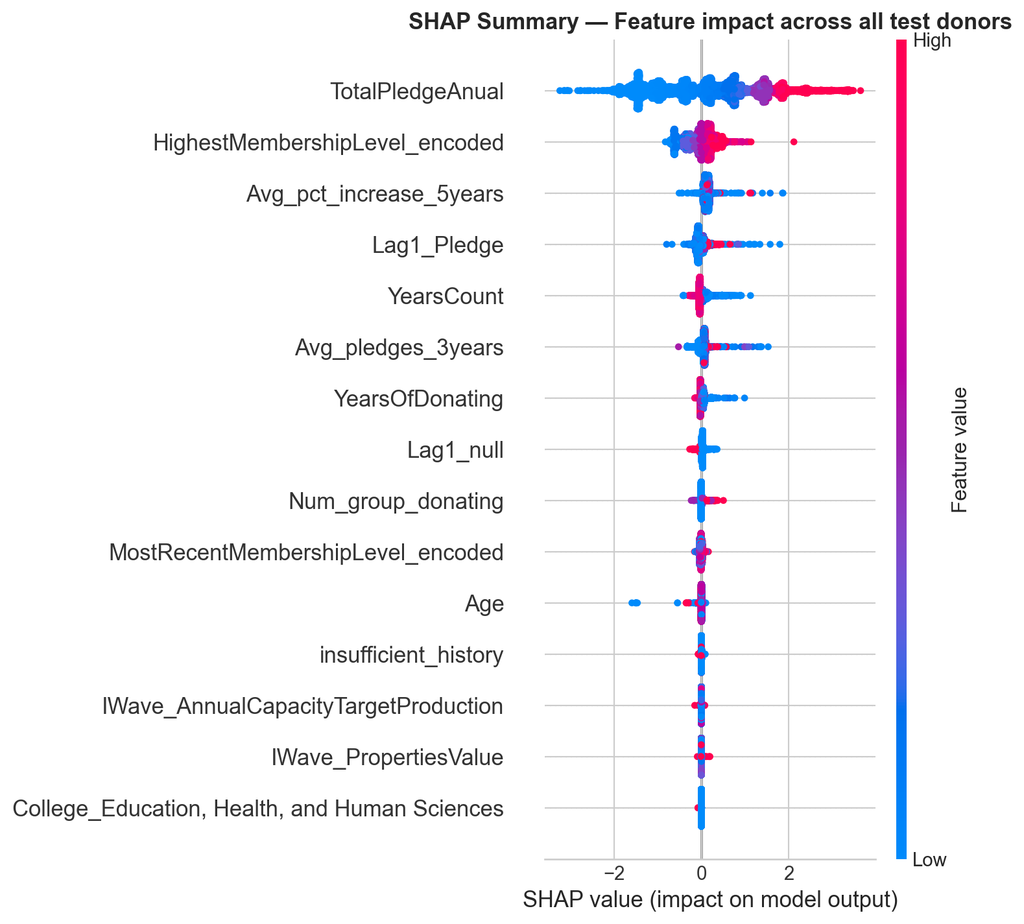

Figure 2: SHAP summary plot: each dot is one donor. Color = feature value (red high, blue low). X-axis position shows directional impact on predicted donation amount.

```python
shap.summary_plot(
    shap_values, X_test,
    max_display=15,
    show=False
)
plt.title('SHAP Summary — Feature impact across all test donors', fontsize=13, fontweight='bold')
plt.tight_layout()
plt.savefig('shap_summary.png', dpi=150, bbox_inches='tight')
plt.show()
plt.close()
```

### Individual Explanations: Two Contrasting Donors

To illustrate how SHAP works in practice, we examine two donors with very different profiles.

```python
# Identify a high-value and a low-value donor in test set
y_pred_test  = xgb_reg.predict(X_test)
high_idx     = np.argmax(y_pred_test)
low_idx      = np.argmin(y_pred_test[y_pred_test > 0])

print(f"High-value donor — predicted: ${np.expm1(y_pred_test[high_idx]):,.0f}")
print(f"Low-value donor  — predicted: ${np.expm1(y_pred_test[low_idx]):,.0f}")
```

```
High-value donor — predicted: $88,984
Low-value donor  — predicted: $0
```

**High-value donor:**

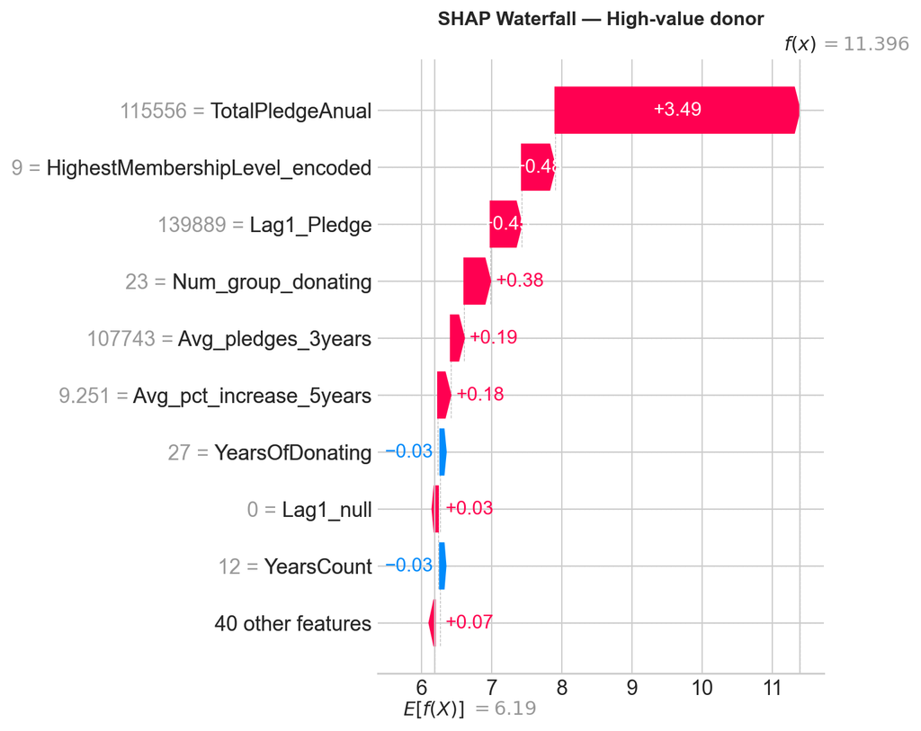

Figure 3: SHAP waterfall for highest-predicted donor. Each bar shows how much one feature pushed the prediction above or below the global expected value.

```python
shap_explanation = explainer(X_test.iloc[[high_idx]])
shap.waterfall_plot(shap_explanation[0], max_display=10, show=False)
plt.title('SHAP Waterfall — High-value donor', fontsize=12, fontweight='bold')
plt.tight_layout()
plt.savefig('shap_waterfall_high.png', dpi=150, bbox_inches='tight')
plt.show()
plt.close()
```

**Low-value donor:**

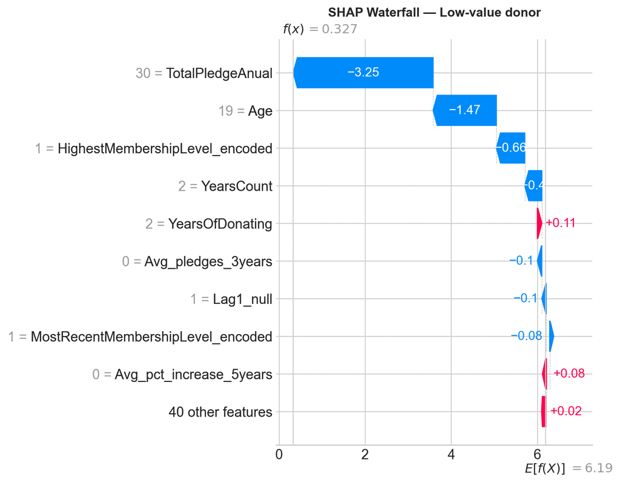

Figure 4: SHAP waterfall for lowest-predicted donor, showing which features suppress the predicted donation amount.

```python
shap_explanation_low = explainer(X_test.iloc[[low_idx]])
shap.waterfall_plot(shap_explanation_low[0], max_display=10, show=False)
plt.title('SHAP Waterfall — Low-value donor', fontsize=12, fontweight='bold')
plt.tight_layout()
plt.savefig('shap_waterfall_low.png', dpi=150, bbox_inches='tight')
plt.show()
plt.close()
```

The waterfall plot reads from bottom to top: starting at the global expected value (E[f(x)]), each bar shows how much a specific feature moved the prediction up (red) or down (blue), arriving at the final predicted amount for that donor.

### Operational Takeaway

SHAP values translate model outputs into fundraiser-readable explanations. Instead of “the model predicts $2,400 for this donor,” a development officer can say: *“This donor’s membership tier and consistent 3-year trend suggest stable giving, but their pledge dropped last year — outreach should focus on re-engagement.”*

This kind of reasoning is only possible when predictions are decomposable. For the segmentation use case, SHAP also allows prioritizing donors not just by predicted amount, but by *which lever* is driving their score — enabling more targeted stewardship strategies.

## Donor Segmentation

The model output alone doesn’t drive decisions — it needs to be translated into actionable groupings for the fundraising team. Each donor is assigned to one of four quadrants defined by two axes:

- **Predicted Amount**: above or below the 75th percentile of predicted donations
- **Historical Reliability**: 100% of pledge years met vs. any miss

**Why percentile for amount but a fixed threshold for reliability?**  
Amount thresholds are context-dependent and change year to year — percentile captures relative standing within the current donor pool. Reliability, on the other hand, is absolute: never having missed a pledge has clear operational meaning that doesn’t need to be relativized.

| Quadrant | Amount | Reliability | Recommended Strategy |
| --- | --- | --- | --- |
| **VIP — Maximum Priority** | High (≥ p75) | 100% | Priority contact, relationship maintenance |
| **High Potential — Needs Follow-up** | High (≥ p75) | < 100% | High value, targeted follow-up strategy |
| **Stable Base** | Low (< p75) | 100% | Reliable, low-touch contact |
| **Low Priority** | Low (< p75) | < 100% | Minimal investment of agent time |

```python
# ── Build segmentation table ──────────────────────────────────────────────────
processed_table = df_processed.copy()
for col in ALL_FEATURES:
    if col not in processed_table.columns:
        processed_table[col] = 0
processed_table[ALL_FEATURES] = processed_table[ALL_FEATURES].apply(pd.to_numeric, errors='coerce').fillna(0)

last_year_by_fan = (
    processed_table.sort_values(['FanID', 'DriveYear'])
    .drop_duplicates('FanID', keep='last')
    .copy()
)
last_year_by_fan['predicted_amount'] = np.expm1(xgb_reg.predict(last_year_by_fan[ALL_FEATURES]))

segmentation_table = (
    last_year_by_fan[['FanID', 'DriveYear', 'predicted_amount']]
    .merge(fan_reliability[['FanID', 'pct_years_met_commitment']], on='FanID', how='left')
)

amount_cutoff = segmentation_table['predicted_amount'].quantile(0.75)

segmentation_table['high_amount']      = segmentation_table['predicted_amount'] >= amount_cutoff
segmentation_table['high_reliability'] = segmentation_table['pct_years_met_commitment'].fillna(0) >= 100.0

segmentation_table['quadrant'] = np.select(
    [
        segmentation_table['high_amount'] & segmentation_table['high_reliability'],
        segmentation_table['high_amount'] & ~segmentation_table['high_reliability'],
        ~segmentation_table['high_amount'] & segmentation_table['high_reliability'],
    ],
    ['VIP — Maximum Priority', 'High Potential — Needs Follow-up', 'Stable Base'],
    default='Low Priority'
)

print(f"Amount threshold (p75): ${amount_cutoff:,.0f}")
print(f"\nDonor distribution by quadrant:")
print(segmentation_table['quadrant'].value_counts().to_string())

# Export for Tableau
segmentation_table.to_csv('segmentation_output.csv', index=False)
print("\n✓ Exported to segmentation_output.csv")
```

```
Amount threshold (p75): $1,300

Donor distribution by quadrant:
quadrant
Stable Base                         17586
VIP — Maximum Priority               6736
Low Priority                         1617
High Potential — Needs Follow-up      251

✓ Exported to segmentation_output.csv
```

```python
amount_cutoff = segmentation_table['predicted_amount'].quantile(0.75)

segmentation_table['high_amount']      = segmentation_table['predicted_amount'] >= amount_cutoff
segmentation_table['high_reliability'] = segmentation_table['pct_years_met_commitment'].fillna(0) >= 100.0

segmentation_table['quadrant'] = np.select(
    [
        segmentation_table['high_amount'] & segmentation_table['high_reliability'],
        segmentation_table['high_amount'] & ~segmentation_table['high_reliability'],
        ~segmentation_table['high_amount'] & segmentation_table['high_reliability'],
    ],
    ['VIP — Maximum Priority', 'High Potential — Needs Follow-up', 'Stable Base'],
    default='Low Priority'
)

# Export for Tableau dashboards
segmentation_table.to_csv('segmentation_output.csv', index=False)
```

The segmentation table was exported for integration into Tableau dashboards, where fundraising agents can filter by quadrant and drill into individual donor profiles.

## Visualizations

### G1: Donor Count by Year

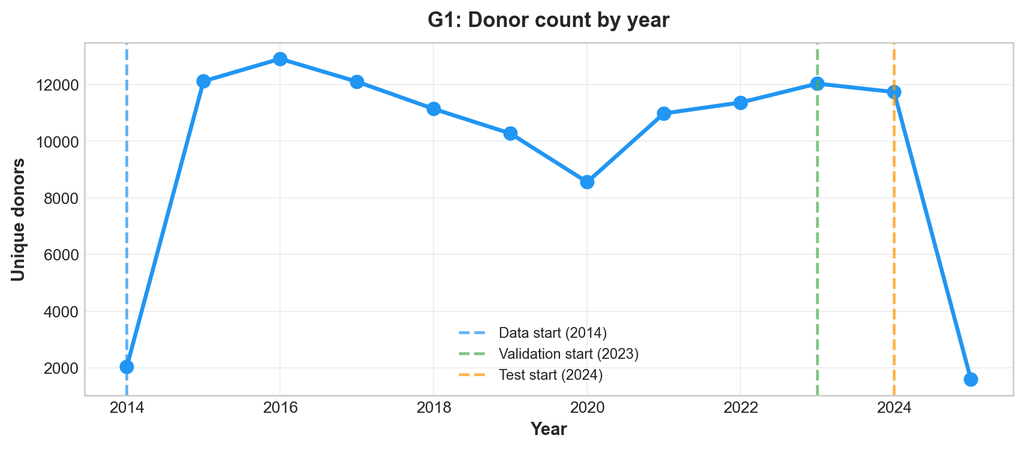

Figure 5: Donor count per year. The drop in 2025 reflects a partial data window, not an actual decline in participation.

```python
fig, ax = plt.subplots(figsize=(9, 4))
_df = df.copy()
donors_by_year = _df.groupby('DriveYear')['FanID'].nunique()
ax.plot(donors_by_year.index, donors_by_year.values,
        marker='o', linewidth=2.5, markersize=8, color=COLORS['train'])
ax.axvline(x=2014, color=COLORS['train'], linestyle='--', linewidth=1.8,
           label='Data start (2014)', alpha=0.7)
ax.axvline(x=2023, color=COLORS['val'],  linestyle='--', linewidth=1.8,
           label='Validation start (2023)', alpha=0.7)
ax.axvline(x=2024, color=COLORS['test'], linestyle='--', linewidth=1.8,
           label='Test start (2024)', alpha=0.7)
ax.set_xlabel('Year', fontsize=11, fontweight='bold')
ax.set_ylabel('Unique donors', fontsize=11, fontweight='bold')
ax.set_title('G1: Donor count by year', fontsize=13, fontweight='bold', pad=10)
ax.legend(fontsize=9)
ax.grid(True, alpha=0.3)
plt.tight_layout()
plt.show()
```

### G2: Geographic Distribution

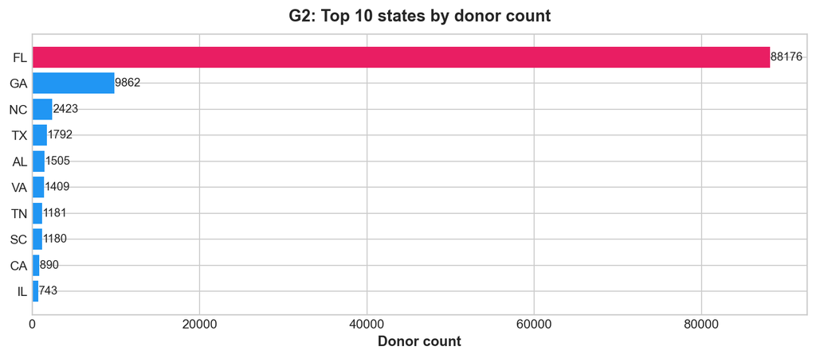

Figure 6: Top 10 states by donor count. Florida (highlighted) accounts for ~75% of all donors, justifying a dedicated `is_florida` flag over full 50-state one-hot encoding.

```python
_df = df.copy()
state_counts  = _df['state'].value_counts().head(10)
colors_states = [COLORS['highlight'] if s == 'FL' else COLORS['train']
                 for s in state_counts.index]

fig, ax = plt.subplots(figsize=(9, 4))
ax.barh(range(len(state_counts)), state_counts.values, color=colors_states)
ax.set_yticks(range(len(state_counts)))
ax.set_yticklabels(state_counts.index)
ax.set_xlabel('Donor count', fontsize=11, fontweight='bold')
ax.set_title('G2: Top 10 states by donor count', fontsize=13, fontweight='bold', pad=10)
ax.invert_yaxis()
for i, v in enumerate(state_counts.values):
    ax.text(v + 30, i, str(v), va='center', fontsize=9)
plt.tight_layout()
plt.show()
```

### G3: Commitment Rate Distribution

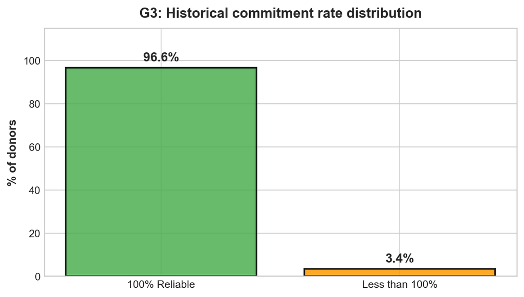

```python
perfect_pct   = (fan_reliability['pct_years_met_commitment'] == 100).mean() * 100
imperfect_pct = 100 - perfect_pct

fig, ax = plt.subplots(figsize=(7, 4))
bars = ax.bar(['100% Reliable', 'Less than 100%'],
              [perfect_pct, imperfect_pct],
              color=[COLORS['val'], COLORS['test']],
              alpha=0.85, edgecolor='black', linewidth=1.5)
ax.set_ylabel('% of donors', fontsize=11, fontweight='bold')
ax.set_title('G3: Historical commitment rate distribution', fontsize=13, fontweight='bold', pad=10)
ax.set_ylim([0, 115])
for bar, val in zip(bars, [perfect_pct, imperfect_pct]):
    ax.text(bar.get_x() + bar.get_width() / 2., bar.get_height() + 2,
            f'{val:.1f}%', ha='center', va='bottom', fontsize=12, fontweight='bold')
plt.tight_layout()
plt.show()
```

### G4: Feature Importance

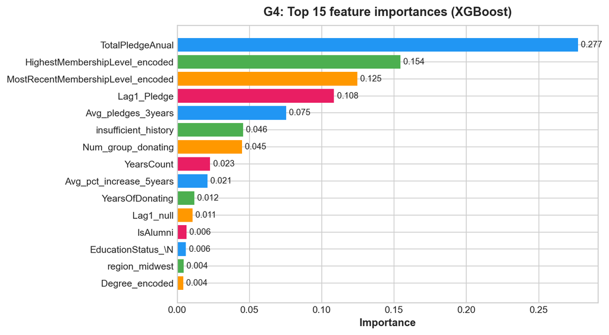

Figure 8: Top 15 XGBoost feature importances. Current pledge amount and membership level account for ~56% of total importance.

```python
fi_sorted      = fi.head(15)
colors_palette = [COLORS['train'], COLORS['val'], COLORS['test'], COLORS['highlight']]

fig, ax = plt.subplots(figsize=(9, 5))
ax.barh(range(len(fi_sorted)), fi_sorted['importance'].values,
        color=[colors_palette[i % 4] for i in range(len(fi_sorted))])
ax.set_yticks(range(len(fi_sorted)))
ax.set_yticklabels(fi_sorted['feature'].values, fontsize=10)
ax.set_xlabel('Importance', fontsize=11, fontweight='bold')
ax.set_title('G4: Top 15 feature importances (XGBoost)', fontsize=13, fontweight='bold', pad=10)
ax.invert_yaxis()
for i, v in enumerate(fi_sorted['importance'].values):
    ax.text(v + 0.002, i, f'{v:.3f}', va='center', fontsize=9)
plt.tight_layout()
plt.show()
```

### G5: Predicted vs. Actual (Validation Set)

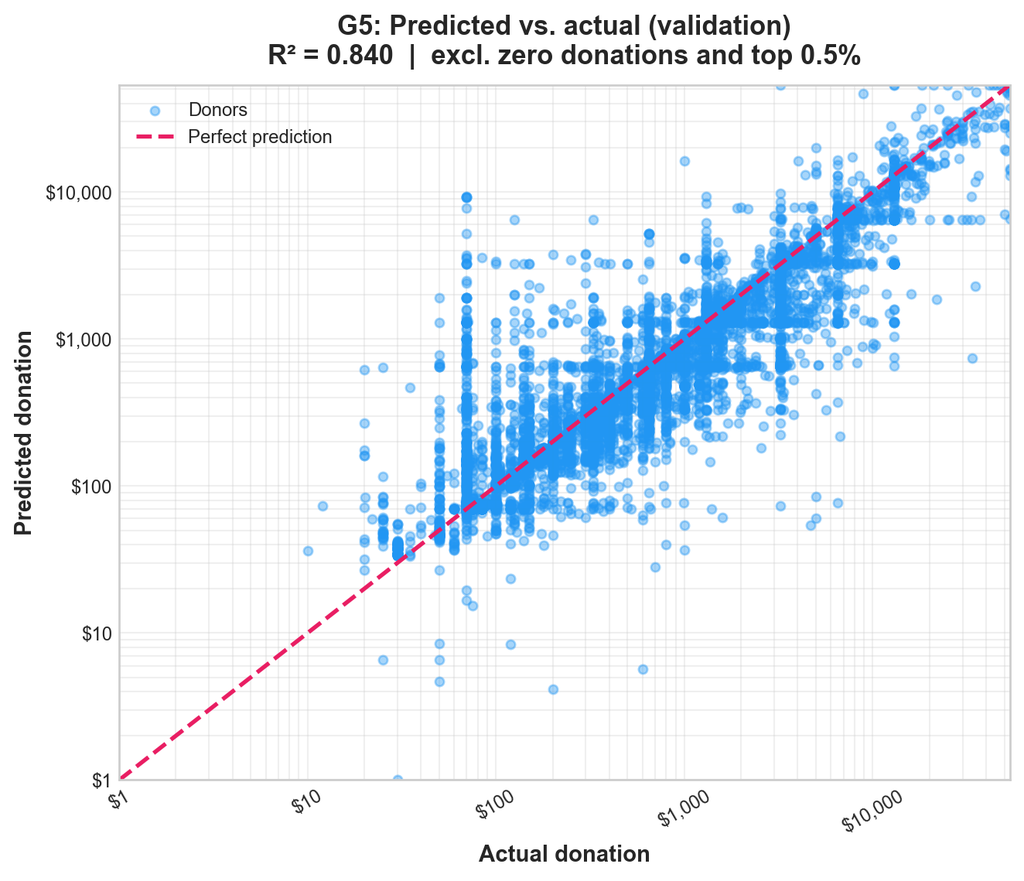

Figure 9: XGBoost predicted vs. actual donation amounts on the validation set (log-log scale, capped at 99.5th percentile). Points close to the diagonal indicate accurate predictions.

```python
y_true_v = y_val.values.astype(float)
y_pred_v = np.expm1(xgb_reg.predict(X_val))
valid_x  = (y_true_v > 0) & (y_pred_v > 0) & np.isfinite(y_true_v) & np.isfinite(y_pred_v)

CAP         = float(np.nanpercentile(y_true_v[valid_x], 99.5))
y_true_plot = np.clip(y_true_v[valid_x], 1.0, CAP)
y_pred_plot = np.clip(y_pred_v[valid_x], 1.0, CAP)
r2_xgb      = r2_score(y_true_plot, y_pred_plot)

fig, ax = plt.subplots(figsize=(7, 6))
ax.scatter(y_true_plot, y_pred_plot, alpha=0.4, s=18, color=COLORS['train'], label='Donors')
ax.plot([1.0, CAP], [1.0, CAP],
        color=COLORS['highlight'], linestyle='--', lw=2, label='Perfect prediction')
ax.set_xscale('log')
ax.set_yscale('log')
ax.set_xlim(1.0, CAP)
ax.set_ylim(1.0, CAP)
tick_vals = [v for v in [1, 10, 100, 1_000, 10_000, 100_000] if 1.0 <= v <= CAP]
ax.set_xticks(tick_vals)
ax.set_yticks(tick_vals)
ax.xaxis.set_major_formatter(mticker.FuncFormatter(lambda x, _: f'${x:,.0f}'))
ax.yaxis.set_major_formatter(mticker.FuncFormatter(lambda x, _: f'${x:,.0f}'))
ax.tick_params(axis='x', labelrotation=30, labelsize=9)
ax.tick_params(axis='y', labelsize=9)
ax.set_xlabel('Actual donation', fontsize=11, fontweight='bold')
ax.set_ylabel('Predicted donation', fontsize=11, fontweight='bold')
ax.set_title(f'G5: Predicted vs. actual (validation)\nR\u00b2 = {r2_xgb:.3f}  |  excl. zero donations and top 0.5%',
             fontsize=13, fontweight='bold', pad=10)
ax.legend(fontsize=9)
ax.grid(True, alpha=0.3, which='both')
plt.tight_layout()
plt.show()
```

### G6: Donor Segmentation Quadrant

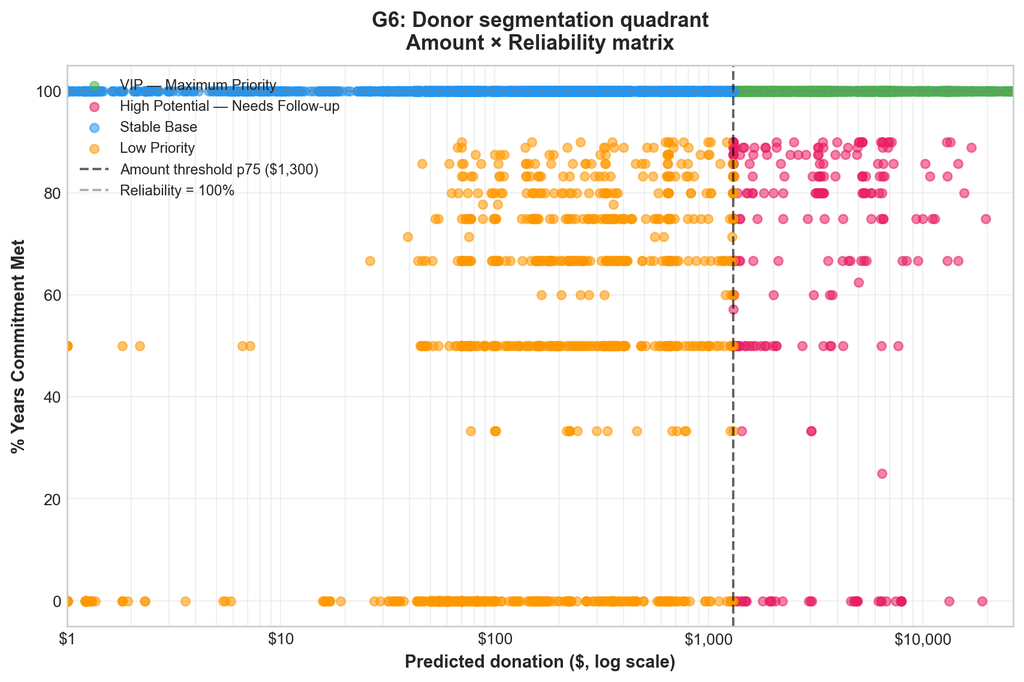

Figure 10: Donor segmentation by predicted amount × historical reliability. Each dot is one donor. Dashed lines mark the p75 amount threshold and the 100% reliability cutoff.

```python
seg = segmentation_table.copy()
seg['predicted_amount'] = (
    seg['predicted_amount']
    .replace([np.inf, -np.inf], np.nan)
    .fillna(1.0)
    .clip(lower=1.0)
)
CAP_G6   = float(np.percentile(seg['predicted_amount'], 99.5))
seg_plot = seg[seg['predicted_amount'] <= CAP_G6].copy()

QUADRANT_COLORS = {
    'VIP — Maximum Priority':           COLORS['val'],
    'High Potential — Needs Follow-up': COLORS['highlight'],
    'Stable Base':                      COLORS['train'],
    'Low Priority':                     COLORS['test'],
}

fig, ax = plt.subplots(figsize=(9, 6))
for q, color in QUADRANT_COLORS.items():
    mask = seg_plot['quadrant'] == q
    ax.scatter(seg_plot.loc[mask, 'predicted_amount'],
               seg_plot.loc[mask, 'pct_years_met_commitment'].fillna(0),
               alpha=0.55, s=30, label=q, color=color)

ax.axvline(x=float(amount_cutoff), color='black', linestyle='--',
           linewidth=1.5, alpha=0.6,
           label=f'Amount threshold p75 (${amount_cutoff:,.0f})')
ax.axhline(y=100, color='gray', linestyle='--', linewidth=1.5,
           alpha=0.6, label='Reliability = 100%')
ax.set_xscale('log')
ax.set_xlim(1.0, CAP_G6)
ax.xaxis.set_major_formatter(mticker.FuncFormatter(lambda x, _: f'${x:,.0f}'))
ax.set_xlabel('Predicted donation ($, log scale)', fontsize=11, fontweight='bold')
ax.set_ylabel('% Years Commitment Met', fontsize=11, fontweight='bold')
ax.set_title('G6: Donor segmentation quadrant\nAmount × Reliability matrix',
             fontsize=13, fontweight='bold', pad=10)
ax.legend(fontsize=9, loc='upper left')
ax.grid(True, alpha=0.3, which='both')
plt.tight_layout()
plt.show()
```

Each chart was designed to tell a specific part of the story:

## Limitations & Future Work

### Known Limitations

**Model scope** — The pipeline applies only to donors with existing pledge history. New or lapsed donors require a separate prospecting model trained on different signals; the `insufficient_history` flag (29% of records) partially addresses this within the current model but does not replace a dedicated architecture.

**Temporal drift** — The model is trained on 2014–2022 behavior and evaluated on 2023–2024. Year-to-year behavioral shifts not captured in historical features (e.g., macroeconomic shocks, institutional changes) will degrade performance on future cohorts without retraining.